# Interest Rate and Default

# 1 Tables

Panel A provides descriptive statistics of the 30% negative equity sample. Panel B provides descriptive statistics of 30% positive equity sample.

## 1.1 Descriptives, 30% Negative Equity

```
##
## ==================================================================================
## Statistic          Mean        St. Dev.   Pctl(25)    Median     Pctl(75)     N
## ----------------------------------------------------------------------------------
## def               0.05386      0.22575        0          0           0      45,282
## prepaid           0.10920      0.31190        0          0           0      45,282
## interestrate      6.24221      0.48238     5.87500    6.25000     6.50000   45,282
## mtg30us           6.19473      0.35824     6.03000    6.24000     6.42000   45,282
## fico             726.99100     52.18561      690        732         769     45,251
## mpay            1,367.01600   550.09690   940.51480 1,286.64900 1,737.41800 45,282
## ltv              90.42821      8.49339       80         95          95      45,282
## dti              38.56706      10.83262      31         39          46      44,431
## upb            207,548.30000 85,329.15000  141,000    195,000     265,000   45,282
## interestrate.1    6.24221      0.48238     5.87500    6.25000     6.50000   45,282
## org_year        2,006.30600    1.30834      2,005      2,006       2,007    45,282
## ne_year         2,009.76000    1.19936      2,009      2,010       2,011    45,282
## ----------------------------------------------------------------------------------
##
```

Back to top

## 1.2 Descriptives, 30% Positive Equity

```
##
## ================================================================================
## Statistic          Mean        St. Dev.   Pctl(25)   Median    Pctl(75)     N
## --------------------------------------------------------------------------------
## def               0.02111      0.14374        0         0          0      54,488
## prepaid           0.15469      0.36162        0         0          0      54,488
## interestrate      5.91740      0.56616     5.62500   5.87500    6.25000   54,488
## mtg30us           5.97604      0.49124     5.72000   5.88000    6.27500   54,488
## fico             727.01150     53.99628      689       735        771     54,488
## mpay            1,045.93800   437.22220   700.28740 974.56670 1,342.81900 54,488
## ltv              77.90655      13.74951      70        80         90      54,488
## dti              35.95226      11.39910      28        36         44      54,488
## upb            177,472.80000 76,666.41000  117,000   165,000    230,000   54,488
## interestrate.1    5.91740      0.56616     5.62500   5.87500    6.25000   54,488
## org_year        2,003.80800    1.75599      2,003     2,004      2,005    54,488
## ne_year         2,009.16400    1.49194      2,008     2,009      2,010    54,488
## --------------------------------------------------------------------------------
##
```

Back to top

## 1.3 Negative Equity sample summary

```
##
## =====================================================
##   ne_cutoff interestrate default_rate prepayment_rate
## -----------------------------------------------------
## 1  -0.500      6.253        6.338          9.641
## 2  -0.400      6.252        6.064          9.818
## 3  -0.300      6.242        5.386         10.920
## 4  -0.200      6.215        4.544         12.489
## 5  -0.100      6.174        3.783         14.449
## -----------------------------------------------------
## In percent
```

Back to top

## 1.4 Positive Equity sample summary

```
##
## =====================================================
##   ne_cutoff interestrate default_rate prepayment_rate
## -----------------------------------------------------
## 1     0        5.986        2.982         15.841
## 2   0.100      5.934        2.059         17.027
## 3   0.200      5.916        1.558         16.366
## 4   0.300      5.921        2.119         15.483
## 5   0.500      6.232        1.806         16.522
## -----------------------------------------------------
## In percent
```

Back to top

## 1.5 Default OLS

This table provides OLS estimates of the relationship between default and interest rate for each negative equity sample. $Default$ equals 1 if the mortgage becomes 60 days delinquent after reaching the respective negative equity threshold.

```
##
## ===================================================================
##                              Y: default ; iv: none
##              ------------------------------------------------------
##
##                 (1)        (2)        (3)        (4)        (5)
## -------------------------------------------------------------------
## fico         -0.0003*** -0.0003*** -0.0004*** -0.0004*** -0.0003***
##              (0.00001)  (0.00002)  (0.00003)  (0.00003)  (0.00004)
## ltv           0.005***   0.005***   0.005***   0.005***   0.003***
##               (0.0004)   (0.0004)   (0.001)    (0.001)    (0.0004)
## log(upb)       0.001      0.004      0.006*    0.010**    0.012**
##               (0.002)    (0.002)    (0.004)    (0.005)    (0.005)
## dti           0.001***   0.001***   0.001***   0.001***   0.001***
##               (0.0001)   (0.0001)   (0.0001)   (0.0002)   (0.0002)
## interestrate  0.033***   0.031***   0.034***   0.032***   0.032***
##               (0.002)    (0.003)    (0.003)    (0.005)    (0.004)
## -------------------------------------------------------------------
##
## Observations  135,392     75,095     44,401     26,452     20,870
## Adjusted R2    0.089      0.076      0.084      0.087      0.094
## ===================================================================
## Note:                                   *p<0.1; **p<0.05; ***p<0.01
##                        Fixed Effects: zip x ne year, zip x org year
##                          Standard Errors clustered by zip x ne year
```

Back to top

## 1.6 Negative Equity, First Stage, Benchmark Rate as Instrument

```
##
## ==============================================================
##                          Y: mpay value ; iv: none
##              -------------------------------------------------
##
##                 (1)       (2)       (3)       (4)       (5)
## --------------------------------------------------------------
## mtg30us      0.725***  0.737***  0.751***  0.759***  0.888***
##               (0.006)   (0.008)   (0.010)   (0.012)   (0.013)
## fico         -0.001*** -0.001*** -0.001*** -0.001*** -0.001***
##              (0.00003) (0.00004) (0.00005) (0.00005) (0.0001)
## ltv          0.007***  0.008***  0.008***  0.009***  0.010***
##              (0.0004)   (0.001)   (0.001)   (0.001)   (0.001)
## log(upb)     -0.185*** -0.182*** -0.181*** -0.181*** -0.178***
##               (0.003)   (0.004)   (0.005)   (0.007)   (0.008)
## dti          0.001***  0.001***  0.001***  0.001***  0.001***
##              (0.0001)  (0.0001)  (0.0002)  (0.0002)  (0.0002)
## --------------------------------------------------------------
##
## Observations  135,392   75,095    44,401    26,452    20,870
## Adjusted R2    0.670     0.592     0.548     0.544     0.538
## ==============================================================
## Note:                              *p<0.1; **p<0.05; ***p<0.01
##                   Fixed Effects: zip x ne year, zip x org year
##                     Standard Errors clustered by zip x ne year
```

Back to top

## 1.7 Negative Equity, First Stage, 10 Year T-bond rate as Instrument

```
##
## ==============================================================
##                          Y: mpay value ; iv: none
##              -------------------------------------------------
##
##                 (1)       (2)       (3)       (4)       (5)
## --------------------------------------------------------------
## gs10         0.385***  0.391***  0.409***  0.423***  0.688***
##               (0.007)   (0.009)   (0.011)   (0.013)   (0.028)
## fico         -0.001*** -0.001*** -0.001*** -0.001*** -0.001***
##              (0.00003) (0.00004) (0.00005) (0.0001)  (0.0001)
## ltv          0.006***  0.008***  0.009***  0.010***  0.012***
##              (0.0004)   (0.001)   (0.001)   (0.001)   (0.001)
## log(upb)     -0.194*** -0.192*** -0.194*** -0.195*** -0.201***
##               (0.004)   (0.005)   (0.006)   (0.008)   (0.011)
## dti          0.002***  0.001***  0.001***  0.001***  0.001***
##              (0.0001)  (0.0001)  (0.0002)  (0.0002)  (0.0003)
## --------------------------------------------------------------
##
## Observations  135,392   75,095    44,401    26,452    20,870
## Adjusted R2    0.614     0.522     0.468     0.466     0.404
## ==============================================================
## Note:                              *p<0.1; **p<0.05; ***p<0.01
##                   Fixed Effects: zip x ne year, zip x org year
##                     Standard Errors clustered by zip x ne year
```

Back to top

## 1.8 Negative Equity, Default IV Regressions, Benchmark Rate as Instrument

```
##
## ==========================================================================
##                                    Y: default ; iv: mtg30us
##                     ------------------------------------------------------
##
##                        (1)        (2)        (3)        (4)        (5)
## --------------------------------------------------------------------------
## fico                -0.0003*** -0.0004*** -0.0004*** -0.0004*** -0.0003***
##                     (0.00002)  (0.00002)  (0.00003)  (0.00004)  (0.00004)
## ltv                  0.005***   0.005***   0.005***   0.005***   0.003***
##                      (0.0004)   (0.0004)   (0.001)    (0.001)    (0.0004)
## log(upb)              -0.001     0.003      0.003      0.007      0.009*
##                      (0.002)    (0.003)    (0.004)    (0.005)    (0.005)
## dti                  0.001***   0.001***   0.001***   0.001***   0.001***
##                      (0.0001)   (0.0001)   (0.0001)   (0.0002)   (0.0002)
## `interestrate(fit)`  0.021***   0.024***   0.018***   0.018**    0.018***
##                      (0.003)    (0.005)    (0.007)    (0.009)    (0.006)
## --------------------------------------------------------------------------
## Cond. F. Stat         2500.1    1544.14    1192.24     816.39     977.71
## Observations         135,392     75,095     44,401     26,452     20,870
## Adjusted R2           0.088      0.076      0.083      0.087      0.093
## ==========================================================================
## Note:                                          *p<0.1; **p<0.05; ***p<0.01
##                               Fixed Effects: zip x ne year, zip x org year
##                                 Standard Errors clustered by zip x ne year
```

Back to top

## 1.9 Negative Equity, Default IV Regressions, 10 Year T-bond rate as Instrument

```
##
## ==========================================================================
##                                    Y: default ; iv: mtg30us
##                     ------------------------------------------------------
##
##                        (1)        (2)        (3)        (4)        (5)
## --------------------------------------------------------------------------
## fico                -0.0003*** -0.0003*** -0.0004*** -0.0003*** -0.0003***
##                     (0.00002)  (0.00002)  (0.00003)  (0.00004)  (0.00004)
## ltv                  0.005***   0.005***   0.005***   0.005***   0.003***
##                      (0.0004)   (0.0004)   (0.001)    (0.001)    (0.0004)
## log(upb)             -0.0002    0.007**     0.008*    0.015***   0.011**
##                      (0.002)    (0.003)    (0.004)    (0.005)    (0.006)
## dti                  0.001***   0.001***   0.001***   0.001***   0.001***
##                      (0.0001)   (0.0001)   (0.0001)   (0.0002)   (0.0002)
## `interestrate(fit)`  0.026***   0.044***   0.042***   0.058***   0.029***
##                      (0.006)    (0.009)    (0.012)    (0.016)    (0.009)
## --------------------------------------------------------------------------
## Cond. F. Stat         662.52     415.6      259.5      234.61     112.32
## Observations         135,392     75,095     44,401     26,452     20,870
## Adjusted R2           0.089      0.076      0.084      0.085      0.093
## ==========================================================================
## Note:                                          *p<0.1; **p<0.05; ***p<0.01
##                               Fixed Effects: zip x ne year, zip x org year
##                                 Standard Errors clustered by zip x ne year
```

Back to top

## 1.10 Positive Equity, Default IV Regressions, Benchmark Rate as Instrument

```
##
## ================================================================================================
##                                               Y: default ; iv: mtg30us
##                     ----------------------------------------------------------------------------
##                         0          10         15         20         25         30         50
##                        (1)        (2)        (3)        (4)        (5)        (6)        (7)
## ------------------------------------------------------------------------------------------------
## fico                -0.0003*** -0.0002*** -0.0003*** -0.0002*** -0.0002*** -0.0003*** -0.0002***
##                     (0.00001)  (0.00001)  (0.00001)  (0.00001)  (0.00001)  (0.00002)  (0.00003)
## ltv                  0.003***   0.002***   0.002***   0.001***   0.001***   0.002***   0.001***
##                      (0.0003)   (0.0002)   (0.0002)   (0.0001)   (0.0002)   (0.0002)   (0.0002)
## log(upb)              -0.002     0.0005     0.001     -0.0001    -0.0002    -0.0004     -0.002
##                      (0.002)    (0.001)    (0.002)    (0.002)    (0.002)    (0.002)    (0.003)
## dti                  0.001***  0.0003***  0.0003***  0.0002***  0.0002***  0.0002***    0.0001
##                     (0.00005)  (0.00004)   (0.0001)  (0.00004)  (0.00005)   (0.0001)   (0.0001)
## `interestrate(fit)`  0.015***   0.011***   0.015***   0.007**     0.004      0.007     0.00003
##                      (0.003)    (0.003)    (0.004)    (0.003)    (0.004)    (0.004)    (0.005)
## ------------------------------------------------------------------------------------------------
##
## Observations         129,645    120,611     88,672     73,542     62,825     54,488     16,803
## Adjusted R2           0.083      0.066      0.069      0.059      0.056      0.058      0.051
## ================================================================================================
## Note:                                                                *p<0.1; **p<0.05; ***p<0.01
##                                                     Fixed Effects: zip x ne year, zip x org year
##                                                       Standard Errors clustered by zip x ne year
```

## 1.11 Control Variables, Benchmark Rate as Instrument

```
##
## ================================================================================
##                                                Dependent variable:
##                                  -----------------------------------------------
##                                      paste(variable, formula_text, sep = "")
##                                       ltv       log(upb)      fico       dti
##                                       (1)          (2)        (3)        (4)
## --------------------------------------------------------------------------------
## `interestrate(fit)`                -1.621***    -0.032**     1.905     1.643***
##                                     (0.294)      (0.013)    (1.631)    (0.301)
## --------------------------------------------------------------------------------
## Observations                        44,401       44,401      44,401     44,401
## R2                                   0.748        0.393      0.054      0.051
## Adjusted R2                          0.741        0.376      0.029      0.025
## Residual Std. Error (df = 43219)     4.309        0.345      51.351     10.697
## ================================================================================
## Note:                                                *p<0.1; **p<0.05; ***p<0.01
##                                     Fixed Effects: zip x ne year, zip x org year
##                                       Standard Errors clustered by zip x ne year
```

Back to top

## 1.12 Control Variables, 10-year T-bond Rate as Instrument

```
##
## ================================================================================
##                                                Dependent variable:
##                                  -----------------------------------------------
##                                      paste(variable, formula_text, sep = "")
##                                       ltv       log(upb)      fico       dti
##                                       (1)          (2)        (3)        (4)
## --------------------------------------------------------------------------------
## `interestrate(fit)`                -5.592***      0.025      5.256*    1.345**
##                                     (0.643)      (0.021)    (2.839)    (0.598)
## --------------------------------------------------------------------------------
## Observations                        44,401       44,401      44,401     44,401
## R2                                   0.680        0.379      0.047      0.051
## Adjusted R2                          0.671        0.362      0.021      0.025
## Residual Std. Error (df = 43219)     4.855        0.349      51.548     10.695
## ================================================================================
## Note:                                                *p<0.1; **p<0.05; ***p<0.01
##                                     Fixed Effects: zip x ne year, zip x org year
##                                       Standard Errors clustered by zip x ne year
```

Back to top

## 1.13 Split by FICO (30% NE Sample), Benchmark Rate as Instrument

```
##
## ===================================================================
##                                Y: default ; iv: mtg30us
##                     -----------------------------------------------
##                       Q1 - 662    Q2 - 712    Q3 - 752    Q4 - 787
##                         (1)          (2)         (3)        (4)
## -------------------------------------------------------------------
## fico                 -0.0004***   -0.0003**   -0.001***   -0.00002
##                       (0.0001)    (0.0001)    (0.0001)    (0.0001)
## ltv                   0.008***    0.005***    0.004***    0.003***
##                       (0.001)     (0.0004)    (0.0003)    (0.0003)
## log(upb)               0.007        0.007      -0.005      0.002
##                       (0.006)      (0.005)     (0.004)    (0.003)
## dti                   0.001***    0.001***    0.0005***  0.0004***
##                       (0.0002)    (0.0001)    (0.0001)    (0.0001)
## `interestrate(fit)`   0.035***    0.026***      0.011     0.018***
##                       (0.012)      (0.009)     (0.008)    (0.007)
## -------------------------------------------------------------------
##
## Observations           18,886      18,849      18,844      18,516
## Adjusted R2            0.075        0.085       0.064      0.063
## ===================================================================
## Note:                                   *p<0.1; **p<0.05; ***p<0.01
##                        Fixed Effects: zip x ne year, zip x org year
##                          Standard Errors clustered by zip x ne year
```

Back to top

## 1.14 Split by FICO (30% NE Sample), 10-year T-bond Rate as Instrument

```
##
## ===================================================================
##                                Y: default ; iv: mtg30us
##                     -----------------------------------------------
##                       Q1 - 662     Q2 - 712    Q3 - 752   Q4 - 787
##                          (1)          (2)        (3)        (4)
## -------------------------------------------------------------------
## fico                 -0.0003***    -0.0002*   -0.001***   -0.00002
##                       (0.0001)     (0.0001)    (0.0001)   (0.0001)
## ltv                   0.008***     0.005***    0.004***   0.002***
##                        (0.001)     (0.0004)    (0.0003)   (0.0003)
## log(upb)                0.010       0.010*      -0.002     0.007*
##                        (0.007)      (0.005)    (0.005)    (0.004)
## dti                   0.001***     0.001***   0.0005***  0.0004***
##                       (0.0002)     (0.0002)    (0.0001)   (0.0001)
## `interestrate(fit)`   0.053***     0.042***    0.030**    0.043***
##                        (0.019)      (0.016)    (0.014)    (0.012)
## -------------------------------------------------------------------
##
## Observations           18,886       18,849      18,844     18,516
## Adjusted R2             0.074        0.086      0.064      0.059
## ===================================================================
## Note:                                   *p<0.1; **p<0.05; ***p<0.01
##                        Fixed Effects: zip x ne year, zip x org year
##                          Standard Errors clustered by zip x ne year
```

Back to top

## 1.15 Judicial, Recourse States (30% Negative Equity), Benchmark Rate as Instrument

```
##
## ===================================================================
##                                Y: Default ; iv: mtg30us
##                     -----------------------------------------------
##                     Non-judicial  Judicial  Non-recourse  Recourse
##                         (1)         (2)         (3)         (4)
## -------------------------------------------------------------------
## fico                 -0.0004***  -0.0004***  -0.0004***  -0.0004***
##                      (0.00003)   (0.00004)   (0.00004)   (0.00003)
## ltv                   0.005***    0.006***    0.005***    0.005***
##                       (0.0003)    (0.0005)    (0.0004)    (0.0003)
## log(upb)               0.001       0.007      0.015**      -0.002
##                       (0.004)     (0.006)     (0.006)     (0.004)
## dti                   0.001***     0.0003     0.001***   0.0004***
##                       (0.0001)    (0.0002)    (0.0002)    (0.0001)
## `interestrate(fit)`   0.018**      0.018       0.006      0.025***
##                       (0.007)     (0.012)     (0.011)     (0.008)
## -------------------------------------------------------------------
##
## Observations           29,390      15,011      15,442      28,959
## Adjusted R2            0.081       0.085       0.079       0.087
## ===================================================================
## Note:                                   *p<0.1; **p<0.05; ***p<0.01
##                        Fixed Effects: zip x ne year, zip x org year
##                          Standard Errors clustered by zip x ne year
```

## 1.16 Judicial, Recourse States (30% Negative Equity), 10-year T-bond Rate as Instrument

```
##
## ===================================================================
##                                Y: Default ; iv: mtg30us
##                     -----------------------------------------------
##                     Non-judicial  Judicial  Non-recourse  Recourse
##                         (1)         (2)         (3)         (4)
## -------------------------------------------------------------------
## fico                 -0.0004***  -0.0004***  -0.0004***  -0.0004***
##                      (0.00003)   (0.00004)   (0.00004)   (0.00003)
## ltv                   0.004***    0.006***    0.005***    0.005***
##                       (0.0003)    (0.0005)    (0.0004)    (0.0003)
## log(upb)               0.005      0.014**     0.021***     0.002
##                       (0.004)     (0.007)     (0.007)     (0.004)
## dti                   0.001***     0.0002     0.001***   0.0004***
##                       (0.0001)    (0.0002)    (0.0002)    (0.0001)
## `interestrate(fit)`   0.037***    0.057**     0.036**     0.045***
##                       (0.012)     (0.022)     (0.018)     (0.013)
## -------------------------------------------------------------------
##
## Observations           29,390      15,011      15,442      28,959
## Adjusted R2            0.081       0.086       0.079       0.087
## ===================================================================
## Note:                                   *p<0.1; **p<0.05; ***p<0.01
##                        Fixed Effects: zip x ne year, zip x org year
##                          Standard Errors clustered by zip x ne year
```

## 1.17 Negative Equity, 50-50 Split by rent-to-value, Benchmark Rate as Instrument

```
##
## ==========================================================================================================================================================
##                                                                            Y: default ; iv: mtg30us
##                     --------------------------------------------------------------------------------------------------------------------------------------
##                     10% low rent 10% high rent 20% low rent 20% high rent 30% low rent 30% high rent 40% low rent 40% high rent 50% low rent 50% high rent
##                         (1)           (2)          (3)           (4)          (5)           (6)          (7)           (8)          (9)          (10)
## ----------------------------------------------------------------------------------------------------------------------------------------------------------
## fico                 -0.0004***   -0.0003***    -0.0004***   -0.0003***    -0.0004***   -0.0005***    -0.0004***   -0.0005***    -0.0003***   -0.0003***
##                      (0.00003)     (0.00003)    (0.00003)     (0.00004)    (0.00004)     (0.0001)      (0.0001)     (0.0001)      (0.0001)     (0.0001)
## ltv                   0.005***     0.003***      0.005***     0.004***      0.005***     0.004***      0.005***     0.005***      0.003***     0.003***
##                       (0.001)       (0.001)      (0.001)       (0.001)      (0.001)       (0.001)      (0.001)       (0.001)      (0.001)       (0.001)
## log(upb)               -0.003        0.002        -0.004        0.007        0.001         0.012        0.010         0.004        0.011         0.015
##                       (0.004)       (0.004)      (0.004)       (0.005)      (0.006)       (0.009)      (0.008)       (0.009)      (0.009)       (0.011)
## dti                   0.001***     0.001***      0.001***     0.001***      0.001***     0.001***      0.001**       0.001**      0.001***     0.001***
##                       (0.0001)     (0.0001)      (0.0001)     (0.0002)      (0.0002)     (0.0002)      (0.0003)     (0.0002)      (0.0003)     (0.0002)
## `interestrate(fit)`   0.020***     0.023***      0.017**        0.016       0.019**        0.020       0.045***      -0.024       0.021**        0.001
##                       (0.007)       (0.007)      (0.008)       (0.011)      (0.009)       (0.013)      (0.014)       (0.015)      (0.010)       (0.013)
## ----------------------------------------------------------------------------------------------------------------------------------------------------------
##
## Observations           39,656       30,242        26,423       19,908        17,611       13,056        11,267        8,307        8,876         6,789
## Adjusted R2            0.078         0.069        0.062         0.066        0.077         0.077        0.077         0.082        0.104         0.077
## ==========================================================================================================================================================
## Note:                                                                                                                          *p<0.1; **p<0.05; ***p<0.01
##                                                                                                               Fixed Effects: zip x ne year, zip x org year
##                                                                                                                 Standard Errors clustered by zip x ne year
```

Back to top

## 1.18 Negative Equity, 50-50 Split by rent-to-value, 10-year T-bond Rate as Instrument

```
##
## ==========================================================================================================================================================
##                                                                            Y: default ; iv: mtg30us
##                     --------------------------------------------------------------------------------------------------------------------------------------
##                     10% low rent 10% high rent 20% low rent 20% high rent 30% low rent 30% high rent 40% low rent 40% high rent 50% low rent 50% high rent
##                         (1)           (2)          (3)           (4)          (5)           (6)          (7)           (8)          (9)          (10)
## ----------------------------------------------------------------------------------------------------------------------------------------------------------
## fico                 -0.0004***   -0.0003***    -0.0004***   -0.0003***    -0.0004***   -0.0004***    -0.0003***   -0.0004***    -0.0003***   -0.0003***
##                      (0.00003)     (0.00003)    (0.00003)     (0.00004)    (0.00004)     (0.0001)      (0.0001)     (0.0001)      (0.0001)     (0.0001)
## ltv                   0.005***     0.003***      0.005***     0.004***      0.005***     0.004***      0.005***     0.004***      0.003***     0.003***
##                       (0.001)       (0.001)      (0.001)       (0.001)      (0.001)       (0.001)      (0.001)       (0.001)      (0.001)       (0.001)
## log(upb)               -0.001        0.003        -0.001       0.011*        0.003        0.022**      0.018**        0.011        0.012        0.019*
##                       (0.004)       (0.004)      (0.005)       (0.006)      (0.006)       (0.010)      (0.009)       (0.010)      (0.009)       (0.011)
## dti                   0.001***     0.001***      0.001***     0.001***      0.001***     0.001***      0.001**       0.001**      0.001***     0.001***
##                       (0.0001)     (0.0001)      (0.0001)     (0.0002)      (0.0002)     (0.0002)      (0.0003)     (0.0002)      (0.0003)     (0.0002)
## `interestrate(fit)`   0.027***      0.028**      0.034**        0.032       0.033**       0.068**      0.092***       0.007        0.022         0.024
##                       (0.011)       (0.012)      (0.013)       (0.020)      (0.015)       (0.027)      (0.027)       (0.024)      (0.015)       (0.017)
## ----------------------------------------------------------------------------------------------------------------------------------------------------------
##
## Observations           39,656       30,242        26,423       19,908        17,611       13,056        11,267        8,307        8,876         6,789
## Adjusted R2            0.079         0.070        0.063         0.066        0.077         0.075        0.071         0.085        0.104         0.080
## ==========================================================================================================================================================
## Note:                                                                                                                          *p<0.1; **p<0.05; ***p<0.01
##                                                                                                               Fixed Effects: zip x ne year, zip x org year
##                                                                                                                 Standard Errors clustered by zip x ne year
```

Back to top

## 1.19 Negative Equity, Prepayments IV Regressions, Benchmark Rate as Instrument

```
##
## =====================================================================
##                                Y: prepayment ; iv: mtg30us
##                     -------------------------------------------------
##                        10%       20%       30%       40%       50%
##                        (1)       (2)       (3)       (4)       (5)
## ---------------------------------------------------------------------
## fico                0.0004*** 0.0004*** 0.0004*** 0.0003*** 0.0003***
##                     (0.00002) (0.00003) (0.00003) (0.00004) (0.00004)
## ltv                 -0.003*** -0.003*** -0.003*** -0.003*** -0.002***
##                     (0.0003)  (0.0004)  (0.0005)  (0.0005)  (0.0004)
## log(upb)            0.107***  0.097***  0.099***  0.083***  0.077***
##                      (0.004)   (0.005)   (0.006)   (0.008)   (0.008)
## dti                 -0.001*** -0.001*** -0.001*** -0.0004** -0.0005**
##                     (0.0001)  (0.0001)  (0.0001)  (0.0002)  (0.0002)
## `interestrate(fit)` 0.047***  0.039***  0.037***  0.047***  0.041***
##                      (0.006)   (0.008)   (0.010)   (0.011)   (0.011)
## ---------------------------------------------------------------------
## Cond. F. Stat        2500.1    1544.14   1192.24   816.39    977.71
## Observations         135,392   75,095    44,401    26,452    20,870
## Adjusted R2           0.087     0.104     0.120     0.118     0.118
## =====================================================================
## Note:                                     *p<0.1; **p<0.05; ***p<0.01
##                          Fixed Effects: zip x ne year, zip x org year
##                            Standard Errors clustered by zip x ne year
```

Back to top

## 1.20 Negative Equity, Prepayments IV Regressions, 10-year T-bond Rate as Instrument

```
##
## ======================================================================
##                                  Y: prepayment ; iv: gs10
##                     --------------------------------------------------
##                        10%        20%       30%       40%       50%
##                        (1)        (2)       (3)       (4)       (5)
## ----------------------------------------------------------------------
## fico                0.0004***  0.0004*** 0.0004*** 0.0003*** 0.0003***
##                     (0.00003)  (0.00003) (0.00003) (0.00004) (0.00004)
## ltv                 -0.003***  -0.003*** -0.003*** -0.003*** -0.002***
##                      (0.0003)  (0.0004)  (0.0005)  (0.0005)  (0.0004)
## log(upb)             0.104***  0.095***  0.100***  0.078***  0.077***
##                      (0.005)    (0.006)   (0.007)   (0.008)   (0.009)
## dti                 -0.0005*** -0.001*** -0.001*** -0.0003*  -0.0005**
##                      (0.0001)  (0.0001)  (0.0001)  (0.0002)  (0.0002)
## `interestrate(fit)`  0.035***   0.028**   0.039**    0.022   0.043***
##                      (0.011)    (0.014)   (0.017)   (0.021)   (0.014)
## ----------------------------------------------------------------------
## Cond. F. Stat         662.52     415.6     259.5    234.61    112.32
## Observations         135,392    75,095    44,401    26,452    20,870
## Adjusted R2           0.088      0.105     0.119     0.120     0.118
## ======================================================================
## Note:                                      *p<0.1; **p<0.05; ***p<0.01
##                           Fixed Effects: zip x ne year, zip x org year
##                             Standard Errors clustered by zip x ne year
```

Back to top

## 1.21 Positive Equity: Prepayment IV Regressions

```
##
## ===================================================================
##                                Y: Prepaid ; iv: mtg30us
##                     -----------------------------------------------
##                         10          30          50
##                         (1)         (2)         (3)         (4)
## -------------------------------------------------------------------
## fico                 0.0005***   0.0005***   0.0005***   0.0004***
##                      (0.00002)   (0.00003)   (0.00003)   (0.0001)
## ltv                  -0.002***   -0.002***   -0.001***   -0.001***
##                      (0.0003)    (0.0003)    (0.0003)     (0.001)
## log(upb)             0.123***    0.133***    0.115***    0.132***
##                       (0.004)     (0.005)     (0.006)     (0.010)
## dti                  -0.001***   -0.001***   -0.001***    -0.0004
##                      (0.0001)    (0.0001)    (0.0001)    (0.0003)
## `interestrate(fit)`  0.067***    0.085***    0.056***    0.073***
##                       (0.008)     (0.008)     (0.010)     (0.016)
## -------------------------------------------------------------------
## Cond. F. Stat         1950.84     1453.47     950.97      933.69
## Observations          129,645     120,611     54,488      16,803
## Adjusted R2            0.091       0.095       0.127       0.126
## ===================================================================
## Note:                                   *p<0.1; **p<0.05; ***p<0.01
##                        Fixed Effects: zip x ne year, zip x org year
##                          Standard Errors clustered by zip x ne year
```

Back to top

# 2 Figures

## 2.1 Non-parametric Evidence, Panel B - Nadaraya–Watson (30% Negative equity sample)

```
##              def
## [1,] 0.007411689
```

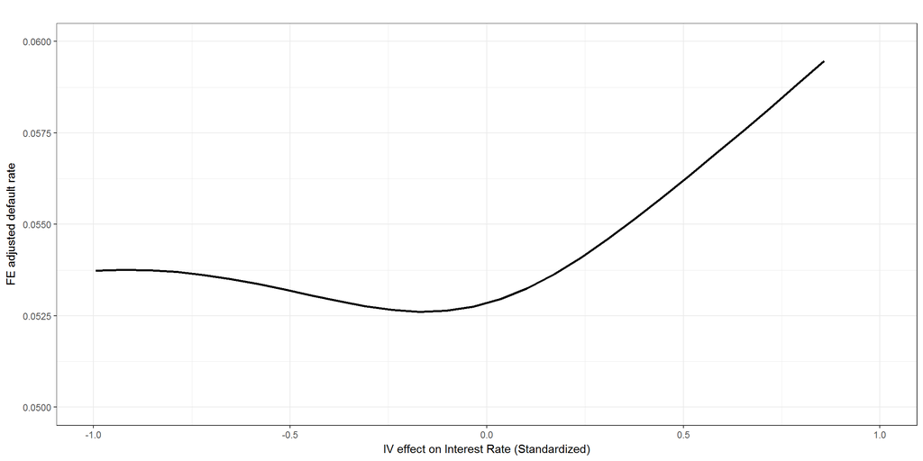

Back to top

## 2.2 Non-parametric Evidence, Panel A - Nadaraya–Watson (30% Negative equity sample)

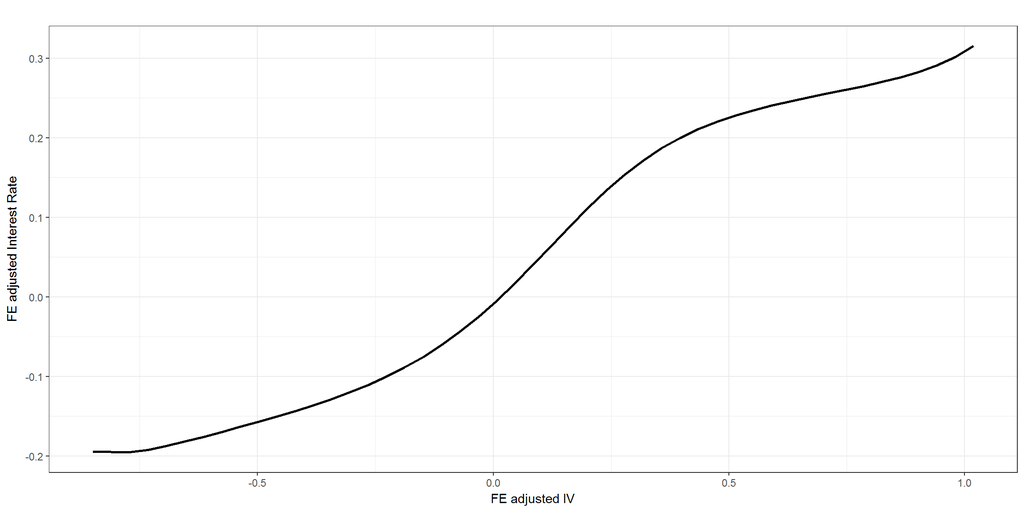

Back to top

## 2.3 Main Result Graph

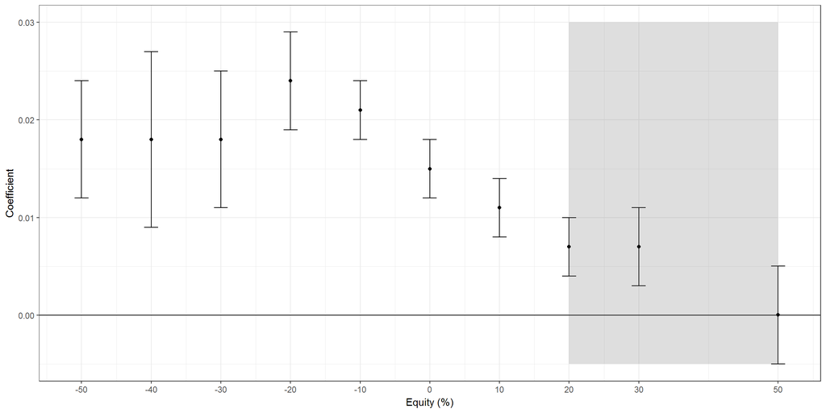

Back to top

# 3 Robustness

## 3.1 Split by price collapse size 1 (10% NE)

```
##
## =====================================================================================
##                                         Y: default ; iv: mtg30us
##                     -----------------------------------------------------------------
##                     Big Collapse (less than median) Small Collapse (more than median)
##                                   (1)                              (2)
## -------------------------------------------------------------------------------------
## fico                          -0.0003***                       -0.0004***
##                                (0.00002)                        (0.00002)
## ltv                            0.004***                         0.009***
##                                (0.0004)                          (0.001)
## log(upb)                        0.004*                          -0.006**
##                                 (0.002)                          (0.003)
## dti                            0.001***                         0.001***
##                                (0.0001)                         (0.0001)
## `interestrate(fit)`            0.024***                         0.018***
##                                 (0.005)                          (0.005)
## -------------------------------------------------------------------------------------
## condf
## Observations                    67,696                           67,515
## Adjusted R2                      0.067                            0.113
## =====================================================================================
## Note:                                                     *p<0.1; **p<0.05; ***p<0.01
##                                          Fixed Effects: zip x ne year, zip x org year
##                                            Standard Errors clustered by zip x ne year
```

## 3.2 Split by price collapse size 1 (30% NE)

```
##
## =====================================================================================
##                                         Y: default ; iv: mtg30us
##                     -----------------------------------------------------------------
##                     Big Collapse (less than median) Small Collapse (more than median)
##                                   (1)                              (2)
## -------------------------------------------------------------------------------------
## fico                          -0.0004***                       -0.0004***
##                                (0.00004)                        (0.00004)
## ltv                            0.004***                         0.008***
##                                 (0.001)                          (0.001)
## log(upb)                       0.016***                          -0.008*
##                                 (0.006)                          (0.005)
## dti                            0.001***                         0.001***
##                                (0.0002)                         (0.0002)
## `interestrate(fit)`             0.020**                          0.018**
##                                 (0.010)                          (0.008)
## -------------------------------------------------------------------------------------
## condf
## Observations                    22,201                           22,135
## Adjusted R2                      0.069                            0.102
## =====================================================================================
## Note:                                                     *p<0.1; **p<0.05; ***p<0.01
##                                          Fixed Effects: zip x ne year, zip x org year
##                                            Standard Errors clustered by zip x ne year
```

## 3.3 Split by time to reach ne cutoff

```
##
## =================================================================
##                               Y: default ; iv: mtg30us
##                     ---------------------------------------------
##                      Less than median (3)   More than median (3)
##                              (1)                    (2)
## -----------------------------------------------------------------
## fico                      -0.0004***             -0.0004***
##                           (0.00004)              (0.00003)
## ltv                        0.005***               0.006***
##                            (0.001)                (0.001)
## log(upb)                   0.010**                 -0.003
##                            (0.005)                (0.006)
## dti                        0.001***               0.001***
##                            (0.0001)               (0.0002)
## `interestrate(fit)`         0.009                 0.035***
##                            (0.008)                (0.011)
## -----------------------------------------------------------------
## condf
## Observations                22,201                 22,200
## Adjusted R2                 0.069                  0.098
## =================================================================
## Note:                                 *p<0.1; **p<0.05; ***p<0.01
##                      Fixed Effects: zip x ne year, zip x org year
##                        Standard Errors clustered by zip x ne year
```

## 3.4 Split by price change in the last 2 years before reaching ne threshold

```
##
## =====================================================================
##                                 Y: default ; iv: mtg30us
##                     -------------------------------------------------
##                     Less than median (-0.32) More than median (-0.32)
##                               (1)                      (2)
## ---------------------------------------------------------------------
## fico                       -0.0004***               -0.0003***
##                            (0.00004)                (0.00004)
## ltv                         0.004***                 0.008***
##                             (0.001)                  (0.001)
## log(upb)                    0.012**                   -0.003
##                             (0.006)                  (0.005)
## dti                         0.001***                 0.001***
##                             (0.0001)                 (0.0002)
## `interestrate(fit)`          0.011                   0.030***
##                             (0.009)                  (0.011)
## ---------------------------------------------------------------------
## condf
## Observations                 22,201                   22,106
## Adjusted R2                  0.069                    0.127
## =====================================================================
## Note:                                     *p<0.1; **p<0.05; ***p<0.01
##                          Fixed Effects: zip x ne year, zip x org year
##                            Standard Errors clustered by zip x ne year
```

## 3.5 3 Digit zip codes with similar price movements across 5-digit zip codes in 2008 - 2012 (30% NE)

```
##
## ===================================================================================
##                                        Y: default ; iv: mtg30us
##                     ---------------------------------------------------------------
##                      p10>0.9   p25>0.9 and p10<=0.9 p50>0.9 and p25<=0.9  p50<=0.9
##                        (1)             (2)                  (3)             (4)
## -----------------------------------------------------------------------------------
## fico                -0.0004***      -0.0005***           -0.0004***      -0.0003***
##                     (0.00004)        (0.0001)             (0.0001)        (0.0001)
## ltv                  0.006***        0.005***             0.005***        0.003***
##                      (0.001)         (0.001)              (0.001)         (0.001)
## log(upb)             0.016**          0.003                -0.004          -0.011
##                      (0.007)         (0.007)              (0.008)         (0.007)
## dti                  0.001***        0.001**              0.0005**        0.0003*
##                      (0.0002)        (0.0002)             (0.0002)        (0.0002)
## `interestrate(fit)`  0.030***         0.011                0.009           0.015*
##                      (0.011)         (0.016)              (0.013)         (0.008)
## -----------------------------------------------------------------------------------
## condf
## Observations          15,777          10,854               10,450          6,872
## Adjusted R2           0.065           0.098                0.065           0.151
## ===================================================================================
## Note:                                                   *p<0.1; **p<0.05; ***p<0.01
##                                        Fixed Effects: zip x ne year, zip x org year
##                                          Standard Errors clustered by zip x ne year
```

## 3.6 3 Digit zip codes with similar price movements across 5-digit zip codes in 2008 - 2012 (10% NE)

```
##
## ===================================================================================
##                                        Y: default ; iv: mtg30us
##                     ---------------------------------------------------------------
##                      p10>0.9   p25>0.9 and p10<=0.9 p50>0.9 and p25<=0.9  p50<=0.9
##                        (1)             (2)                  (3)             (4)
## -----------------------------------------------------------------------------------
## fico                -0.0003***      -0.0004***           -0.0004***      -0.0003***
##                     (0.00003)       (0.00004)            (0.00003)       (0.00003)
## ltv                  0.005***        0.005***             0.005***        0.004***
##                      (0.001)         (0.001)              (0.001)         (0.001)
## log(upb)              0.003           0.003                -0.004         -0.005*
##                      (0.004)         (0.005)              (0.003)         (0.003)
## dti                  0.001***        0.001***             0.001***        0.001***
##                      (0.0001)        (0.0001)             (0.0001)        (0.0001)
## `interestrate(fit)`  0.035***        0.020**              0.021***         0.009*
##                      (0.007)         (0.009)              (0.006)         (0.006)
## -----------------------------------------------------------------------------------
## condf
## Observations          32,003          29,743               35,327          36,932
## Adjusted R2           0.062           0.090                0.072           0.138
## ===================================================================================
## Note:                                                   *p<0.1; **p<0.05; ***p<0.01
##                                        Fixed Effects: zip x ne year, zip x org year
##                                          Standard Errors clustered by zip x ne year
```

## 3.7 Negative Equity, Default IV Regressions, Benchmark Rate as Instrument, Quarterly Fixed Effects

```
##
## ==========================================================================
##                                    Y: default ; iv: mtg30us
##                     ------------------------------------------------------
##
##                        (1)        (2)        (3)        (4)        (5)
## --------------------------------------------------------------------------
## fico                -0.0004*** -0.0004*** -0.0004*** -0.0004*** -0.0003***
##                     (0.00001)  (0.00002)  (0.00003)  (0.00003)  (0.00004)
## ltv                  0.001***  0.0005***    0.0003    -0.0001    -0.0003
##                      (0.0001)   (0.0002)   (0.0002)   (0.0003)   (0.0004)
## log(upb)             -0.004**    -0.001     -0.001     0.002      -0.003
##                      (0.002)    (0.002)    (0.003)    (0.005)    (0.006)
## dti                  0.001***   0.001***   0.001***   0.001***   0.001***
##                      (0.0001)   (0.0001)   (0.0001)   (0.0001)   (0.0002)
## `interestrate(fit)`  0.012***   0.011***    0.005      0.006      0.001
##                      (0.002)    (0.003)    (0.005)    (0.006)    (0.007)
## --------------------------------------------------------------------------
## Cond. F. Stat         9468.4    3822.63    1361.06     663.39     908.63
## Observations         135,392     75,095     44,401     26,452     20,870
## Adjusted R2           0.050      0.044      0.042      0.053      0.045
## ==========================================================================
## Note:                                          *p<0.1; **p<0.05; ***p<0.01
##                                   Fixed Effects: zip x ne qt, zip x org qt
##                                   Standard Errors clustered by zip x ne qt
```

## 3.8 Negative Equity, Default IV Regressions, 10-year T-bond Rate as Instrument, Quarterly Fixed Effectss

```
##
## ==========================================================================
##                                     Y: default ; iv: gs10
##                     ------------------------------------------------------
##
##                        (1)        (2)        (3)        (4)        (5)
## --------------------------------------------------------------------------
## fico                -0.0004*** -0.0004*** -0.0004*** -0.0004*** -0.0003***
##                     (0.00001)  (0.00002)  (0.00003)  (0.00003)  (0.00004)
## ltv                  0.001***  0.0005***    0.0002    -0.0002    -0.0003
##                      (0.0001)   (0.0002)   (0.0002)   (0.0003)   (0.0004)
## log(upb)             -0.003**    -0.001     0.001      0.004      -0.004
##                      (0.002)    (0.002)    (0.003)    (0.005)    (0.006)
## dti                  0.001***   0.001***   0.001***   0.001***   0.001***
##                      (0.0001)   (0.0001)   (0.0001)   (0.0001)   (0.0002)
## `interestrate(fit)`  0.013***   0.011**    0.017**     0.017*     -0.006
##                      (0.003)    (0.005)    (0.008)    (0.010)    (0.012)
## --------------------------------------------------------------------------
## Cond. F. Stat         660.51     213.81       84       63.59       69.9
## Observations         135,392     75,095     44,401     26,452     20,870
## Adjusted R2           0.050      0.044      0.042      0.053      0.043
## ==========================================================================
## Note:                                          *p<0.1; **p<0.05; ***p<0.01
##                                   Fixed Effects: zip x ne qt, zip x org qt
##                                   Standard Errors clustered by zip x ne qt
```